# Demo: simulation function and visualizing results

J. Kirby and M. Sonderegger

2018-03-16

This file explains how to carry out the kind of analysis shown in the main paper, in more user-friendly fashion than the code. Code is illustrated from:

- `runSimsJPhon.R` : run the exact simulations in the paper
- `powerEs.R`:functions to carry out simulations used to approximate power and Type M/S error
- `summarizeVisualizeRuns.R`: functions to summarize and visualize results

# 1. Run simulations

Load and process Roettger et al. data:

```r
library(lme4)
library(arm)
library(plyr)
library(dplyr)
library(ggplot2)
library(simr)


E1 = read.csv("roettgerEtAlData.csv",comment.char="")
E1 <- E1[-481,]

## turn items, subjects into factors
E1$item_pair = as.factor(E1$item_pair)
E1$subject = as.factor(E1$subject)

## center voicing variable
E1$voiceless <- rescale(E1$voicing)
```

Fit a mixed model to the R2014 data:

```r
mod  <- lmer(vowel_dur ~ voiceless  + accent_type + prosodic_boundary + place + vowel + norming_voiceless_count + (1+voiceless|subject) + (1+voiceless|item_pair),
              data=E1)
```

These two things are done by executing

```r
source('powerEs.R')
```

which also contains definitions of the functions `sampleNewDataset`, `runSim`, and `runSweep`.

Each call to `runSim` runs a simulation for fixed parameter values. For example, to run a simulation with `nSim=100` for the actual parameter values for the Roettger et al. (2014) data:

```r
useParallel <- FALSE
runs <- runSim(E1.mdl, nS=16, nI=24, nRep=1, beta=-9, nSims=100)
```

Each row of the resulting dataframe corresponds to a single model, fitted to simulated data:

```r
head(runs)
```

```
##        beta      lrTestP lrTestModSelect nS nI nRep   n trueBeta nSims
## 1 -5.690683 0.0166211386             yes 16 24    1 749       -9   100
## 2 -5.935006 0.0237349384             yes 16 24    1 749       -9   100
## 3 -7.768839 0.0039619644             yes 16 24    1 749       -9   100
## 4 -7.652624 0.0009894834             yes 16 24    1 749       -9   100
## 5 -7.852720 0.0007338118             yes 16 24    1 749       -9   100
## 6 -8.508623 0.0027021394             yes 16 24    1 749       -9   100
```

The `runSweep` function runs simulations for a range of parameter values (one simulation = one call to `runSim`). For example, to carry out simulations across the parameter values shown in Table 1 of the paper, with `nSims=1500`, you use the code in `runSimsJphon.R`:

```r
useParallel <- TRUE
nCores <- 25

if(useParallel){
    library(doMC)
    registerDoMC(nCores)
    getDoParWorkers()
}
runSweep(mod=origMod, betaVals=seq(-2, -10),
         nSVals <- seq(6,26,4),
         nIVals <- seq(10,30,5),
         nRepVals <- seq(1,6),
         nSims=1500,
         saveFName = 'runs_16Mar18_nRuns1500.rds')
```

Note that:

- The simulation sweeps automatically execute in parallel, if you specify a number of cores and use the `useParallel` option
- The code directly above will take a very long time (days), so it is not recommended to execute it on a laptop. Instead, we execute it on a remote server, and save the resulting runs as an RDS file.

# 2. Summarize and visualize results

To load in the the results from an RDS file:

```r
runs <- readRDS("runs_16Mar18_nRuns1500.rds")
```

The file `summarizeVisualizeRuns.R` contains several functions to calculate power and Type M/S error based on these runs:

```r
library(dplyr)
library(tidyr)
library(ggplot2)

binomEst <- function(n1, n){
    if(n>0){
        temp <- binom.test(n1, n)
        return(c(temp$conf.int[1], temp$conf.int[2], as.numeric(temp$estimate)))
    } else{
        return(c(NA, NA, NA))
    }
}

normalEst <- function(x){
    m <- mean(x, na.rm=TRUE)
    se <- sd(x, na.rm = TRUE)/sqrt(length(which(!is.na(x))))
    return(c(m, m-1.96*se, m+1.96*se))
}

## function to compute summary df for power -- estimate, and lower and upper bounds
## for 95% CI --
## as a function of all input vars, just using LR model selection strategy
##
powerSummary <- function(x){

    powerVals <- function(nSig, n){
        temp <- binom.test(nSig, n)
        return(c(temp$conf.int[1], temp$conf.int[2], as.numeric(temp$estimate)))
    }

    summaryDf <- x %>% group_by(nS,nI,nRep, trueBeta) %>%
        dplyr::summarise(nSig=sum(lrTestModSelect=='yes'), n=n()) %>%
        group_by(nS,nI,nRep, trueBeta, n, nSig) %>%
        do(setNames(data.frame(t(powerVals(.$nSig, .$n))), c('power_lower', 'power_upper', 'power')))

    return(summaryDf)

}



## make plottable dataframe for just for just typeM and typeS error,
## broken down by whether conditional on significance, non-significance, or using both.
typeMSSummary <-  function(x){



    ## summary for typeM
    tempDf1 <- x %>% mutate(betaRat = abs(beta)/abs(trueBeta), sameSign=(sign(beta)==sign(trueBeta))) %>%
        group_by(nS,nI,nRep, trueBeta) %>%
        do(
            cbind(
                setNames(data.frame(t(normalEst(.$betaRat))),
                         c('typeM_both_est', 'typeM_both_lower', 'typeM_both_upper')),
                setNames(data.frame(t(normalEst(ifelse(.$lrTestModSelect=='yes',.$betaRat,  NA)))),
                          c('typeM_sig_est', 'typeM_sig_lower', 'typeM_sig_upper')),
                setNames(data.frame(t(normalEst(ifelse(.$lrTestModSelect=='no',.$betaRat,  NA)))),
                         c('typeM_ns_est', 'typeM_ns_lower', 'typeM_ns_upper'))
            )
        )


    tempDf2 <- x %>% mutate(sameSign=(sign(beta)==sign(trueBeta))) %>%
        group_by(nS,nI,nRep, trueBeta) %>%
        dplyr::summarise(nSig=sum(lrTestModSelect=='yes'), n=n(),
                  nSigRightSign=sum(sameSign & lrTestModSelect=='yes'),
                  nNsRightSign=sum(sameSign & lrTestModSelect=='no'),
                  power = nSig/n()) %>%
        group_by(nS,nI,nRep, trueBeta, power) %>%
        do(
            cbind(
                setNames(data.frame(t(binomEst(.$n-.$nSigRightSign -.$nNsRightSign, .$n))), c('typeS_both_lower', 'typeS_both_upper', 'typeS_both_est')),
                setNames(data.frame(t(binomEst(.$nSig-.$nSigRightSign, .$nSig))), c('typeS_sig_lower', 'typeS_sig_upper', 'typeS_sig_est')),
                setNames(data.frame(t(binomEst(.$n-.$nSig-.$nNsRightSign, .$n-.$nSig))), c('typeS_ns_lower', 'typeS_ns_upper', 'typeS_ns_est'))
            )
        )
     tempDf <- left_join(tempDf1, tempDf2)

    tempDf <- tempDf %>% gather("key", "val", starts_with("type")) %>%
        separate(key, into=c('var','sig','measure')) %>%
        unite(measure, var, measure) %>%
        spread(measure, val)
    return(tempDf)

}
```

For example, let’s consider just the “low sample size” case from the paper: 6 subjects, 10 items, 1 repetition, for a range of effect sizes:

```r
lowSubset <- filter(runs, nS==6 & nI==10 & nRep==1)
```

To calculate power and Type M/S error using these simulation runs, for each unique value of the effect size:

```r
powerSumm <- powerSummary(lowSubset)
typeMsSumm <- typeMSSummary(lowSubset)
```

For example, the power dataframe:

```r
powerSumm
```

```
## # A tibble: 9 x 9
## # Groups:   nS, nI, nRep, trueBeta, n, nSig [9]
##      nS    nI  nRep trueBeta     n  nSig power_lower power_upper
##   <dbl> <dbl> <int>    <int> <int> <int>       <dbl>       <dbl>
## 1     6    10     1      -10  1500   615  0.38497383  0.43537927
## 2     6    10     1       -9  1500   544  0.33829239  0.38757996
## 3     6    10     1       -8  1500   410  0.25090813  0.29664942
## 4     6    10     1       -7  1500   368  0.22374070  0.26792757
## 5     6    10     1       -6  1500   265  0.15768052  0.19692767
## 6     6    10     1       -5  1500   183  0.10585638  0.13963941
## 7     6    10     1       -4  1500   166  0.09523131  0.12764435
## 8     6    10     1       -3  1500    89  0.04791714  0.07251025
## 9     6    10     1       -2  1500    81  0.04311186  0.06667295
## # ... with 1 more variables: power <dbl>
```

shows that the estimated power for effect size -8 is 0.273, with 95% CI (0.251, 0.297).

We can now plot power as a function of effect size (like Fig. 4 in the paper), showing a dotted line at the customary 80% cutoff value:

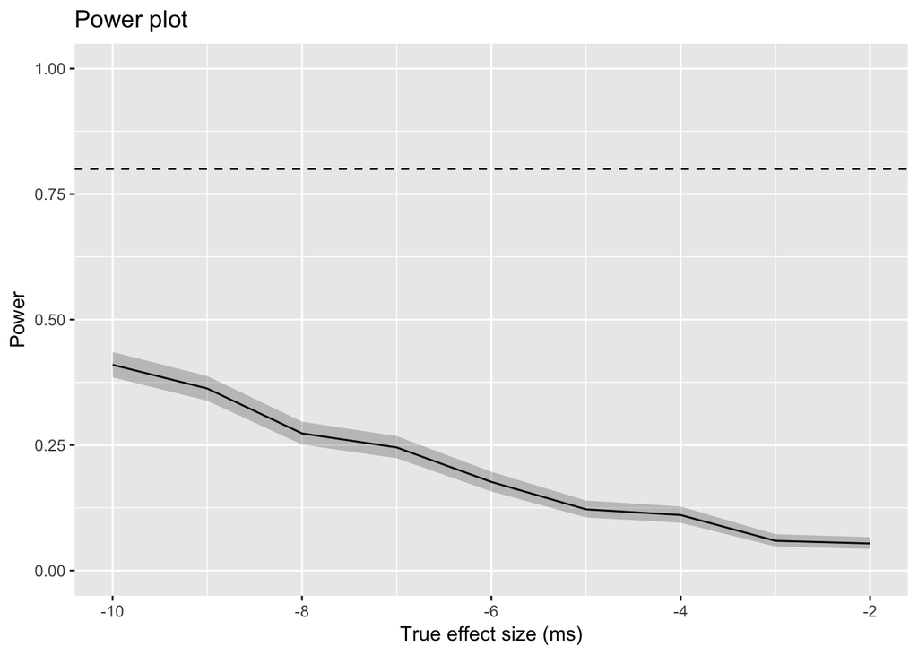

```r
ggplot(aes(x=trueBeta, y=power), data=powerSumm) +
    geom_line() +
    geom_ribbon(aes(ymin=power_lower, ymax=power_upper), alpha=0.25) + geom_hline(yintercept=0.8, lty=2) + ylim(0,1) +
    xlab("True effect size (ms)") + ylab("Power") + geom_hline(yintercept=0.8, lty=2) + theme_set(theme_bw()) + ggtitle("Power plot")
```

We can also plot Type M and Type S error as a function of effect size, using separate panels to show values conditioned on significance, or calculated across all runs:

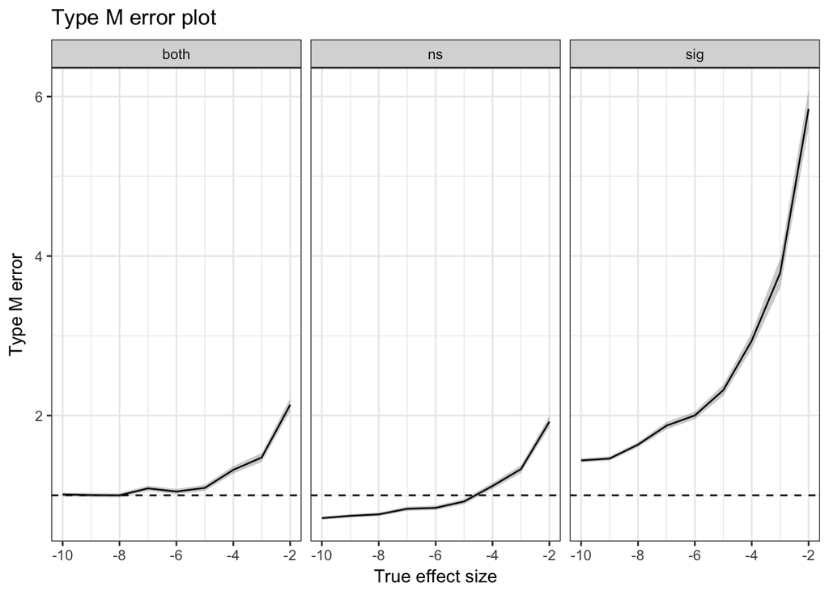

```r
 ggplot(aes(x=trueBeta, y=typeM_est), data = typeMsSumm) +
    geom_line() +
    geom_ribbon(aes(ymin=typeM_lower, ymax=typeM_upper), alpha=0.25) +
    xlab("True effect size") + ylab("Type M error")  +
    geom_hline(yintercept=1, lty=2) +  theme_set(theme_bw())  +
    facet_wrap(~sig) + theme_set(theme_bw()) + ggtitle("Type M error plot")
```

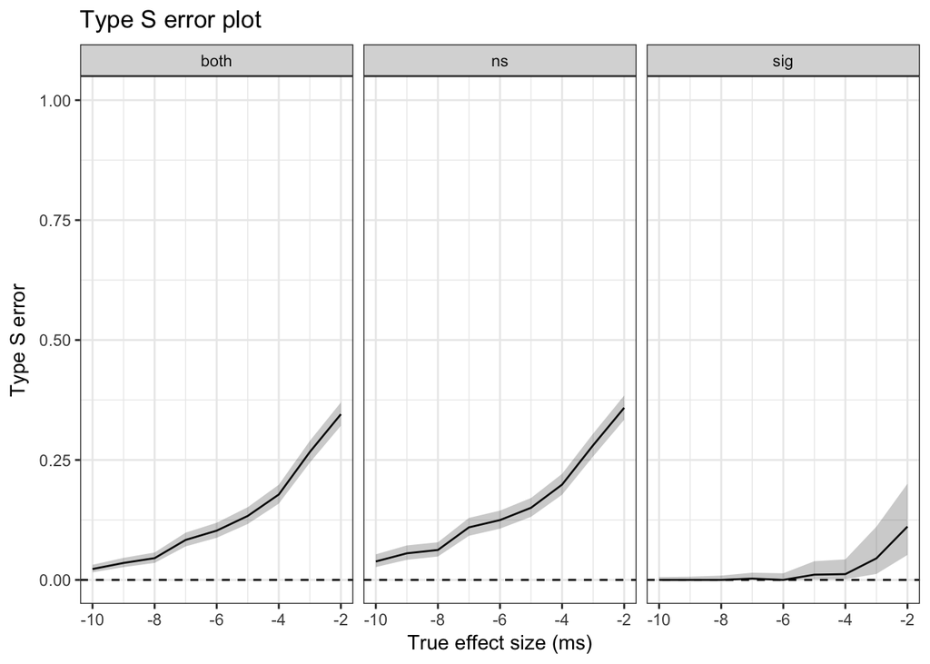

```r
ggplot(aes(x=trueBeta, y=typeS_est), data = typeMsSumm) +
    geom_line() +
    geom_ribbon(aes(ymin=typeS_lower, ymax=typeS_upper), alpha=0.25) + theme_set(theme_bw())  +
    xlab("True effect size") + ylab("Type S error") + xlab("True effect size (ms)")  + geom_hline(yintercept=0, lty=2) +
    facet_wrap(~sig) +  theme_set(theme_bw()) + ylim(0,1) + ggtitle("Type S error plot")
```